# EDA - Scheduling Classifier

Walt Wells, 2018

# Overview

### Stated Problem

> For this assignment, build a classifier that will help a company improve its appointment scheduling process. This model must both:
> 1. make future predictions and
> 2. provide insights and intelligence to business leaders about what they can improve.

> Anticipate that the findings must be accessible to a non-technical audience but withstand interrogation from technically sophisticated clients.

> You may provide results in any format that you wish, although we are partial to RMarkdown. There is no need to go overboard attempting to make a very accurate model or putting a lot of polish on the deliverables. We are more interested in how you would approach this, including understanding the nuance of the problem, than actually doing so here, so please give us enough detail to do that but this doesn’t have to be “client ready”.

### Resources

Most initial data prep and EDA was done on my local machine. If we were to simply dummy code the initial dataset prior to feature engineering/variable selection, the dataset size would grow by a power of 3. As a result, it was useful to have a secondary workspace of a 4 core VM running RStudio Server in Google Compute Platform to handle larger tasks like feature selection and model training.

# Environment Prep

```r
if (!require('doMC')) install.packages('doMC')
if (!require('dplyr')) install.packages('dplyr')
if (!require('ggplot2')) install.packages('ggplot2')
if (!require('wesanderson')) install.packages('wesanderson')
if (!require('cowplot')) install.packages('cowplot')
if (!require('lubridate')) install.packages('lubridate')
if (!require('Boruta')) install.packages('Boruta')
if (!require('caret')) install.packages('caret')
if (!require('e1071')) install.packages('e1071')
if (!require('tictoc')) install.packages('tictoc')

# setup parallel processing to speed up model training when on GCP
registerDoMC(cores = 4)

# basic plot settings
theme_set(theme_minimal())
theme_update(plot.title = element_text(hjust = 0.5))
```

# Load Data

```r
dictionary <- read.csv('data/2017-12-20_HW1_data_dictionary.csv')
appts <- read.csv('data/2017-12-20_HW1_data.csv', stringsAsFactors = T)
```

# Data Prep: Initial

```r
results <- appts$appt_status
appts$appt_status <- NULL

## Create binary version of outcome variable
binresults <- as.character(results)
binresults[binresults != "Show"] <- "NotServed"
binresults[binresults == "Show"] <- "Served"
binresults <- as.factor(binresults)
```

### Typing

```r
nums <- appts[,c(1,5:7,9:12)]
dates <- appts[,c(2:4, 8)]
```

Let’s also prepare the date times, including setting up an “hour” variable, and removing the vars for scheduled date and injury date as the important information is better represented in the “weeksfrom” types of variables.

```r
hour <- as.numeric(gsub(":.*", "", dates$scheduletime))
dates$scheduletime <- NULL

dates$scheduleddate <- NULL
dates$injury_date <- NULL
dates$appointment <- as.Date(dates$appointment)

appts <- cbind(nums, dates, hour, results, binresults)

names(appts)[names(appts) == 'scheduledappointment'] <- 'weeksappt'
names(appts)[names(appts) == 'injuryscheduled'] <- 'weeksinjury'

rm(dates, nums, binresults, hour, results)
```

### NA Checker

```r
NAcheck <- function(df){
    index <- sapply(df,function(x)sum(is.na(x)))
    newdf <- data.frame(index = names(df),Missing_Values=index)
    newdf[newdf$Missing_Values > 0,]
}
NAcheck(appts)
```

```
## [1] index          Missing_Values
## <0 rows> (or 0-length row.names)
```

# EDA

```r
table(appts$business_line)
```

```
##
##   L1   L2   L3   L4   L5   L6
##   19 1288  959    3   40 2691
```

```r
table(appts$doctor_specialty)
```

```
##
##   L1  L10  L11   L2   L3   L4   L5   L6   L7   L8   L9
##  695   78    6  114   93  270    1   76 2959  525  183
```

```r
table(appts$jurisdiction)
```

```
##
## L10 L11 L12 L13 L14 L15 L16 L17 L18 L19 L20 L21 L23 L24 L25 L26 L27 L28
## 620  28  43   2   7   4 421   1  15   3   4   8  77   9   6  13   5   3
## L29 L30 L31 L32 L33 L34 L35 L36 L38 L39  L4 L40 L41 L45 L48  L5 L50 L52
## 194  78   2 220 154   2   5   2  13   4   9   7   8 809   4   2   2 902
## L53 L54 L55 L57 L58 L59 L60 L61 L62 L64 L65 L66 L67 L68 L69  L8
## 107   5 292  65  13   4   7   3 219  11  10   9 332 148  50  39
```

### EDA: Plot of Service / Service_Type

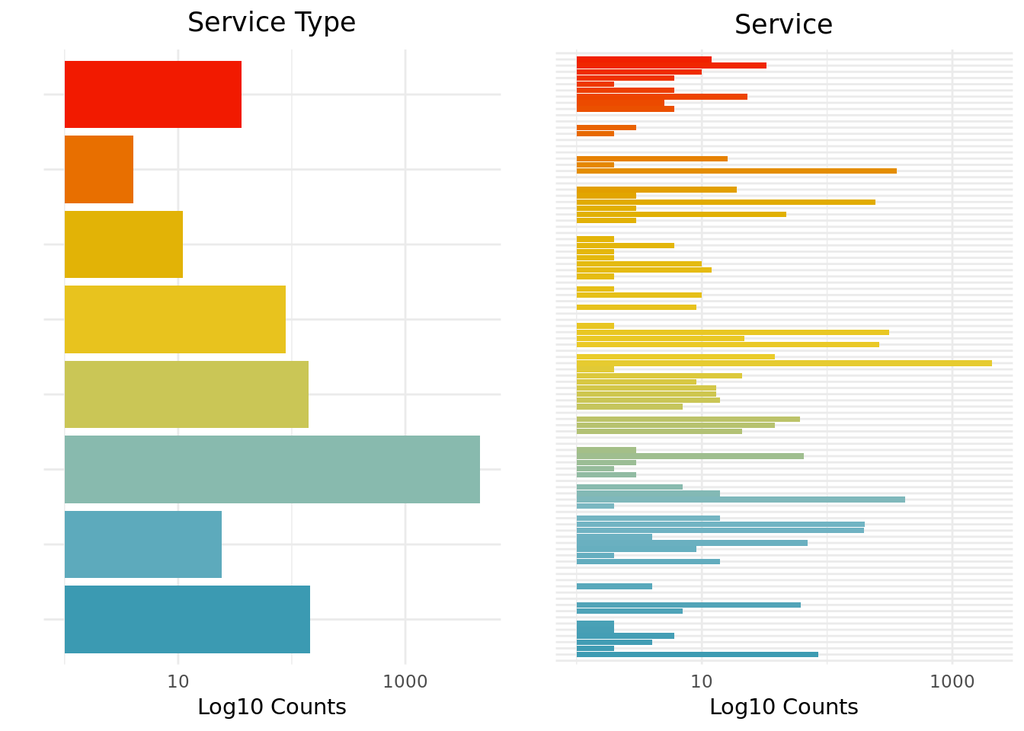

```r
p1 <- ggplot(appts, aes(x=service_type, fill=service_type)) +
    geom_bar() +
    scale_y_log10() +
    ylab("Log10 Counts") +
    xlab("") +
    theme(axis.text.y=element_blank(),
          axis.ticks.y=element_blank()) +
    ggtitle("Service Type") +
    scale_fill_manual(values = wes_palette("Zissou", nlevels(appts$service_type), type="continuous")) +
    coord_flip()

p2 <- ggplot(appts, aes(x=service, fill=service)) +
    geom_bar() +
    scale_y_log10() +
    ylab("Log10 Counts") +
    xlab("") +
    theme(axis.text.y=element_blank(),
          axis.ticks.y=element_blank()) +
    ggtitle("Service") +
    scale_fill_manual(values = wes_palette("Zissou", nlevels(appts$service), type="continuous")) +
    coord_flip()

p <- plot_grid( p1 + theme(legend.position="none"),
           p2 + theme(legend.position="none"),
           align = 'vh',
           hjust = -1,
           nrow = 1
           )
p
```

### EDA: Histograms - Variable of Interest

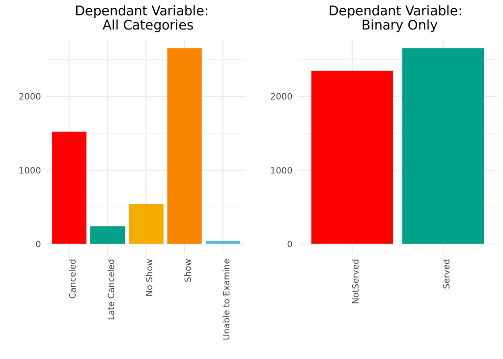

```r
p1 <- ggplot(data=appts, aes(x=results, fill=results)) +
    geom_bar() +
    ylab("") +
    xlab("") +
    ggtitle("Dependant Variable:  \n All Categories") +
    scale_fill_manual(values = wes_palette("Darjeeling")) +
    theme(axis.text.x = element_text(angle = 90, hjust = 1))

p2 <- ggplot(data=appts, aes(x=binresults, fill=binresults)) +
    geom_bar() +
    ylab("") +
    xlab("") +
    ggtitle("Dependant Variable: \n Binary Only") +
    scale_fill_manual(values = wes_palette("Darjeeling")) +
    theme(axis.text.x = element_text(angle = 90, hjust = 1))

p <- plot_grid( p1 + theme(legend.position="none"),
           p2 + theme(legend.position="none"),
           align = 'vh',
           hjust = -1,
           nrow = 1
           )
p
```

Let’s move forward using our binary feature of “Served/NotServed” as our predictor. That’s a lot of cancellations and no-shows! No wonder the client is looking to improve their scheduling process.

```r
appts$results <- NULL
```

### EDA: Trends over Time

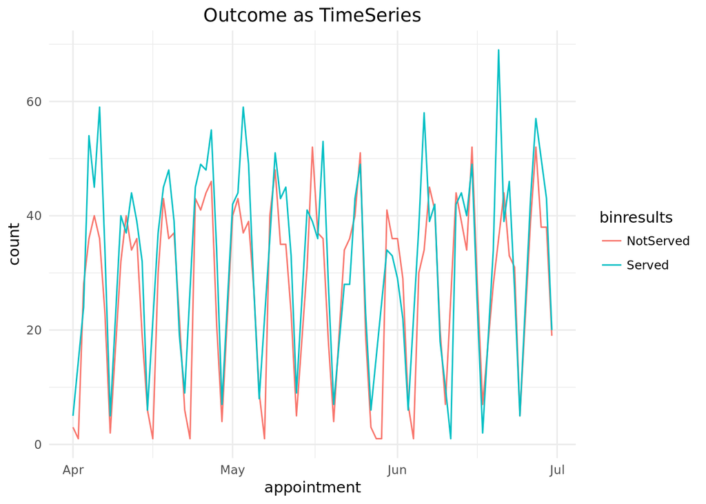

```r
df <- appts %>%
     group_by(appointment, binresults) %>%
     summarise(count=n())

ggplot(df, aes(appointment, count, color=binresults)) +
    geom_line() +
    ggtitle("Outcome as TimeSeries")
```

Let’s add a factor for day of the week since we see a clear pattern in the plot above.

```r
appts$apptdayofweek <- wday(appts$appointment, label=T)
```

### EDA: Plot of Weekday

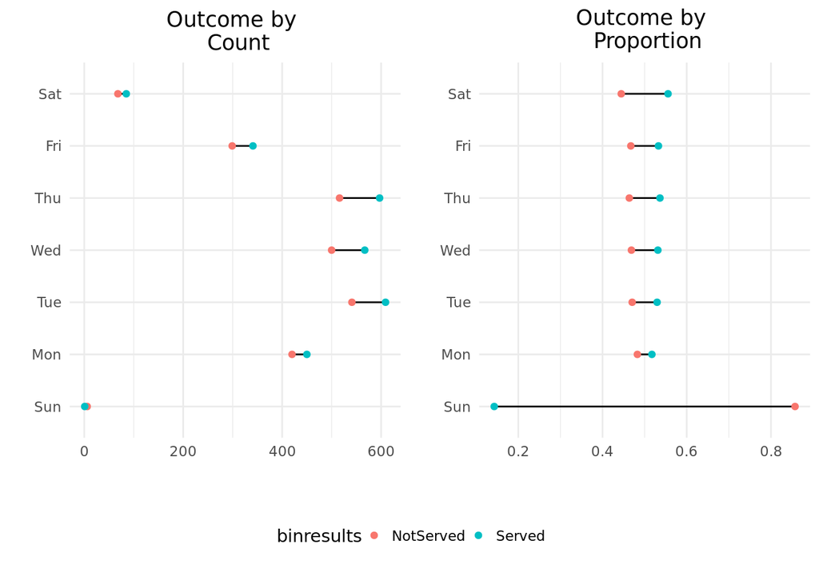

```r
df <- appts %>%
    group_by(apptdayofweek, binresults) %>%
    summarise(count=n()) %>%
    mutate(proportion = count / sum(count))

p1 <- ggplot(df, aes(apptdayofweek, count, fill = binresults)) +
    geom_line(aes(group=apptdayofweek)) +
    geom_point(aes(color=binresults)) +
    coord_flip() +
    ggtitle("Outcome by \n Count") +
    ylab("") +
    xlab("")

p2 <- ggplot(df, aes(apptdayofweek, proportion, fill = binresults)) +
    geom_line(aes(group=apptdayofweek)) +
    geom_point(aes(color=binresults)) +
    coord_flip() +
    ggtitle("Outcome by \n Proportion") +
    ylab("") +
    xlab("")

prow <- plot_grid( p1 + theme(legend.position="none"),
           p2 + theme(legend.position="none"),
           align = 'vh',
           hjust = -1,
           nrow = 1
           )

legend_b <- get_legend(p1 + theme(legend.position="bottom"))
p <- plot_grid(prow, legend_b, ncol = 1, rel_heights = c(1, .2))
p
```

Once we are looking at proportions, this doesn’t look substantially different from day to day - slightly higher degree of negatives on Mondays. We could perform additional statistical tests to dive deeper, but for now, let’s move on.

# Data Prep: Secondary

### Categorical: Combining Levels Helper Function

We can see from our initial tables of categorical variables and some of the EDA visualizations that we will need to combine a number of levels in order to improve classifier performance. Let’s build a helper function so we can apply it to all our unordered categorical variables. The helper will look at a categorical variable, then combine all variables that occur at a frequency level under a particular threshold into a new category - “Other”.

```r
combineLevels <- function(varname, freq) {
  # combine non-ordinal categorical variables with a frequency under a given threshold
  #
  # Args:
  #   varname: variable of interest
  #   freq:  replace all vars below this frequency
  #
  # Returns:
  #   newvec:  a vector of factors to replace original categorical variable
  newvec <- as.character(appts[[varname]])
  freq_df <- appts %>%
    group_by(appts[[varname]]) %>%
    summarise(n = n()) %>%
    mutate(freq = n/sum(n))

  combine <- as.character(freq_df[1][freq_df$freq < freq,][[1]])

  newvec[newvec %in% combine] <- "Other"
  newvec <- as.factor(newvec)
  return(newvec)
}
```

### Combining Levels Example

```r
freq <- .02 #combine observations below this frequency
table(appts$doctor_specialty)
```

```
##
##   L1  L10  L11   L2   L3   L4   L5   L6   L7   L8   L9
##  695   78    6  114   93  270    1   76 2959  525  183
```

```r
appts$doctor_specialty <- combineLevels('doctor_specialty', freq)
table(appts$doctor_specialty)
```

```
##
##    L1    L2    L4    L7    L8    L9 Other
##   695   114   270  2959   525   183   254
```

### Combining Levels: All

```r
appts$business_line <- combineLevels("business_line", freq)
appts$jurisdiction <- combineLevels("jurisdiction", freq)
appts$service <- combineLevels("service", freq)
appts$company_external <- combineLevels("company_external", freq)
appts$service_type <- combineLevels("service_type", freq)
appts$apptdayofweek <- combineLevels("apptdayofweek", freq)
```

# Feature Selection

We’ll use a few packaged algorithms to explore feature selection.

For our initial explorations, we’ll use the Boruta Algorithm to help us find the most important features for our modeling. https://cran.r-project.org/web/packages/Boruta/Boruta.pdf

### Feature Selection using Boruta Algorithm

```r
set.seed(121)
bor.results <- Boruta(binresults ~., data = appts,
                      maxRuns = 101,
                      doTrace = 0)
```

#### Plotting Boruta Results

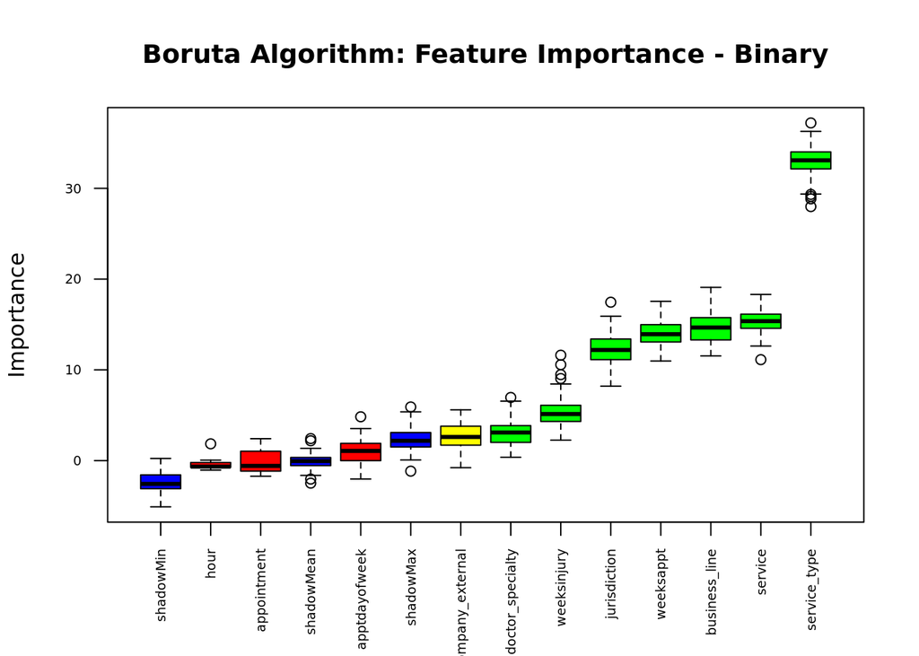

```r
plot(bor.results, las = 2,
     xlab = '',
     main = 'Boruta Algorithm: Feature Importance - Binary',
     space = 1,
     cex.axis = .6)
```

### Feature Selection using Recursive Feature Elemination (RFE)

To supplement or Boruta Algorithm and dive deeper into the Dummy encoding of our many deidentified categorical variables, we’ll use RFE in the caret package.

```r
set.seed(121)
tic("RFE Selection")
control <- rfeControl(functions = rfFuncs,
                      method = "repeatedcv",
                      number = 10,
                      repeats = 5)
# run the RFE algorithm
results <- rfe(binresults ~., data = appts,
               metric = "Accuracy",
               sizes = c(2:25, 30, 35, 40, 45, 50, 55, 60),
               rfeControl = control)

# list the chosen features
predictors(results)
```

```
##  [1] "service_typeL3"        "serviceOther"
##  [3] "business_lineL6"       "weeksappt"
##  [5] "weeksinjury"           "service_typeL4"
##  [7] "jurisdictionL55"       "jurisdictionL29"
##  [9] "business_lineL3"       "business_lineOther"
## [11] "serviceL33"            "doctor_specialtyL7"
## [13] "company_externalL262"  "jurisdictionL67"
## [15] "apptdayofweekOther"    "serviceL3"
## [17] "doctor_specialtyOther" "appointment"
## [19] "apptdayofweekTue"      "jurisdictionL53"
## [21] "serviceL53"            "jurisdictionOther"
## [23] "serviceL58"            "doctor_specialtyL8"
## [25] "doctor_specialtyL9"    "jurisdictionL16"
## [27] "apptdayofweekMon"      "company_externalL634"
## [29] "jurisdictionL45"       "jurisdictionL33"
## [31] "company_externalL380"  "jurisdictionL68"
## [33] "jurisdictionL62"       "company_externalL27"
## [35] "serviceL77"
```

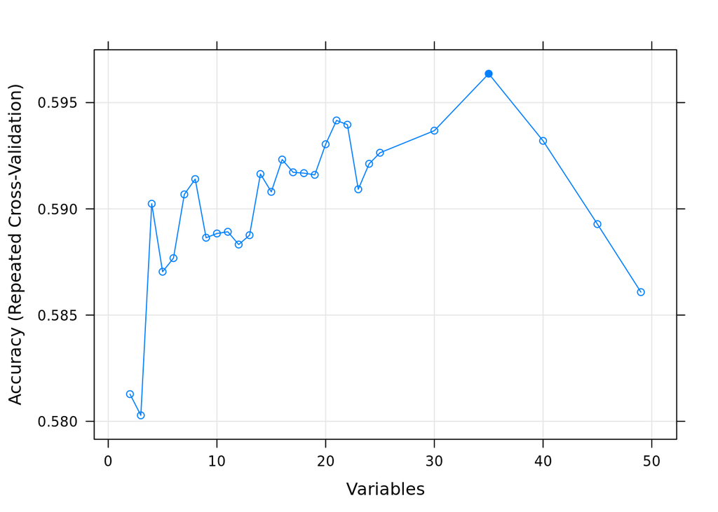

```r
# plot the results
plot(results, type = c("g", "o"))
```

```r
toc()
```

```
## RFE Selection: 2420.531 sec elapsed
```

# Data Prep: Final

### Subset for Modeling

For now, let’s use the recommendations from the RFE method above about which features are most important, dummy encode our dataset, and subset acccordingly so that it’s ready for modeling.

```r
binresults <- appts$binresults
appts$binresults <- NULL
dummy <- dummyVars(" ~ .", data = appts)
dummydf <- data.frame(predict(dummy, newdata = appts))

name <- names(dummydf)
name <- gsub("[.]", "", name)
names(dummydf) <- name

apptssub <- subset(dummydf, select = c(results$optVariables))
apptssub$binresults <- binresults

# clean house
rm(dummydf, dummy)
```

# Modeling

We’ll train a few vanilla classifiers and compaire their performance. We’ll look at a Decision Tree, Random Forest, SVM, Naive Bayes and Neural Net. No real time will be spent tuning the models to improve performance. We just want to establish a baseline. We will use “Accuracy” as our initial vanilla performance metric.

### Train/Test Split

```r
set.seed(121)
TrainingDataIndex <- createDataPartition(apptssub$binresults,
                                         p = 0.85,
                                         list = FALSE)

trainingData <- apptssub[TrainingDataIndex,]
testData <- apptssub[-TrainingDataIndex,]

ctrl <- trainControl(method = "repeatedcv",
                     number = 10,
                     repeats = 5)
```

### Decision Tree

```r
tic("Decision Tree Train")
set.seed(121)
DT_Model <- train(binresults ~ ., data = trainingData,
                  method = "C5.0",
                  preProcess = c("scale","center"),
                  trControl = ctrl)
toc()
```

```
## Decision Tree Train: 56.882 sec elapsed
```

```r
tic("Decision Tree Predict")
DT_Predictions <- predict(DT_Model, testData)

cmDT <- confusionMatrix(DT_Predictions, testData$binresults)
cmDT
```

```
## Confusion Matrix and Statistics
##
##            Reference
## Prediction  NotServed Served
##   NotServed        51     11
##   Served          301    386
##
##                Accuracy : 0.5834
##                  95% CI : (0.5472, 0.619)
##     No Information Rate : 0.53
##     P-Value [Acc > NIR] : 0.001868
##
##                   Kappa : 0.1229
##  Mcnemar's Test P-Value : < 2.2e-16
##
##             Sensitivity : 0.14489
##             Specificity : 0.97229
##          Pos Pred Value : 0.82258
##          Neg Pred Value : 0.56186
##              Prevalence : 0.46996
##          Detection Rate : 0.06809
##    Detection Prevalence : 0.08278
##       Balanced Accuracy : 0.55859
##
##        'Positive' Class : NotServed
##
```

```r
toc()
```

```
## Decision Tree Predict: 0.319 sec elapsed
```

### Random Forest

```r
tic("Random Forest Train")
set.seed(121)

RF_Model <- train(binresults ~ ., data = trainingData,
                  method = "rf",
                  preProcess = c("scale","center"),
                  trControl = ctrl)
toc()
```

```
## Random Forest Train: 457.097 sec elapsed
```

```r
tic("Random Forest Predict")
RF_Predictions <- predict(RF_Model, testData)

cmRF <- confusionMatrix(RF_Predictions, testData$binresults)
cmRF
```

```
## Confusion Matrix and Statistics
##
##            Reference
## Prediction  NotServed Served
##   NotServed        96     38
##   Served          256    359
##
##                Accuracy : 0.6075
##                  95% CI : (0.5715, 0.6426)
##     No Information Rate : 0.53
##     P-Value [Acc > NIR] : 1.168e-05
##
##                   Kappa : 0.1834
##  Mcnemar's Test P-Value : < 2.2e-16
##
##             Sensitivity : 0.2727
##             Specificity : 0.9043
##          Pos Pred Value : 0.7164
##          Neg Pred Value : 0.5837
##              Prevalence : 0.4700
##          Detection Rate : 0.1282
##    Detection Prevalence : 0.1789
##       Balanced Accuracy : 0.5885
##
##        'Positive' Class : NotServed
##
```

```r
toc()
```

```
## Random Forest Predict: 0.251 sec elapsed
```

### SVM

```r
tic("SVM Train")
set.seed(121)

SVM_Model <- train(binresults ~ ., data = trainingData,
                 method = "svmRadial",
                 trControl= ctrl,
                 preProcess = c("pca","scale","center"))
toc()
```

```
## SVM Train: 132.095 sec elapsed
```

```r
tic("SVM Predict")
SVM_Predictions <- predict(SVM_Model, testData)

cmSVM <- confusionMatrix(SVM_Predictions, testData$binresults)
cmSVM
```

```
## Confusion Matrix and Statistics
##
##            Reference
## Prediction  NotServed Served
##   NotServed       120     50
##   Served          232    347
##
##                Accuracy : 0.6235
##                  95% CI : (0.5877, 0.6583)
##     No Information Rate : 0.53
##     P-Value [Acc > NIR] : 1.518e-07
##
##                   Kappa : 0.2215
##  Mcnemar's Test P-Value : < 2.2e-16
##
##             Sensitivity : 0.3409
##             Specificity : 0.8741
##          Pos Pred Value : 0.7059
##          Neg Pred Value : 0.5993
##              Prevalence : 0.4700
##          Detection Rate : 0.1602
##    Detection Prevalence : 0.2270
##       Balanced Accuracy : 0.6075
##
##        'Positive' Class : NotServed
##
```

```r
toc()
```

```
## SVM Predict: 0.426 sec elapsed
```

### Naive Bayes

```r
tic("Naive Bayes Train")
set.seed(121)
NB_Model <- train(binresults ~ ., data = trainingData,
                 method = "nb",
                 trControl = ctrl,
                 preProcess = c("scale","center"))
toc()
```

```
## Naive Bayes Train: 42.698 sec elapsed
```

```r
tic("Naive Bayes Predict")
NB_Predictions <- predict(NB_Model, testData)

cmNB <- confusionMatrix(NB_Predictions, testData$binresults)
cmNB
```

```
## Confusion Matrix and Statistics
##
##            Reference
## Prediction  NotServed Served
##   NotServed        44      5
##   Served          308    392
##
##                Accuracy : 0.5821
##                  95% CI : (0.5459, 0.6177)
##     No Information Rate : 0.53
##     P-Value [Acc > NIR] : 0.002357
##
##                   Kappa : 0.1182
##  Mcnemar's Test P-Value : < 2.2e-16
##
##             Sensitivity : 0.12500
##             Specificity : 0.98741
##          Pos Pred Value : 0.89796
##          Neg Pred Value : 0.56000
##              Prevalence : 0.46996
##          Detection Rate : 0.05874
##    Detection Prevalence : 0.06542
##       Balanced Accuracy : 0.55620
##
##        'Positive' Class : NotServed
##
```

```r
toc()
```

```
## Naive Bayes Predict: 2.02 sec elapsed
```

### Neural Nets

```r
tic("Neural Nets Train")
set.seed(121)
NN_Model <- train(binresults ~ ., data = trainingData,
                 method = "nnet",
                 trControl = ctrl,
                 preProcess = c("scale","center"))
toc()
```

```
## Neural Nets Train: 100.88 sec elapsed
```

```r
tic("Neural Nets Predict")
NN_Predictions <- predict(NN_Model, testData)

cmNN <- confusionMatrix(NN_Predictions, testData$binresults)
cmNN
```

```
## Confusion Matrix and Statistics
##
##            Reference
## Prediction  NotServed Served
##   NotServed       126     77
##   Served          226    320
##
##                Accuracy : 0.5955
##                  95% CI : (0.5593, 0.6308)
##     No Information Rate : 0.53
##     P-Value [Acc > NIR] : 0.0001826
##
##                   Kappa : 0.168
##  Mcnemar's Test P-Value : < 2.2e-16
##
##             Sensitivity : 0.3580
##             Specificity : 0.8060
##          Pos Pred Value : 0.6207
##          Neg Pred Value : 0.5861
##              Prevalence : 0.4700
##          Detection Rate : 0.1682
##    Detection Prevalence : 0.2710
##       Balanced Accuracy : 0.5820
##
##        'Positive' Class : NotServed
##
```

```r
toc()
```

```
## Neural Nets Predict: 0.222 sec elapsed
```

### Feature Importance

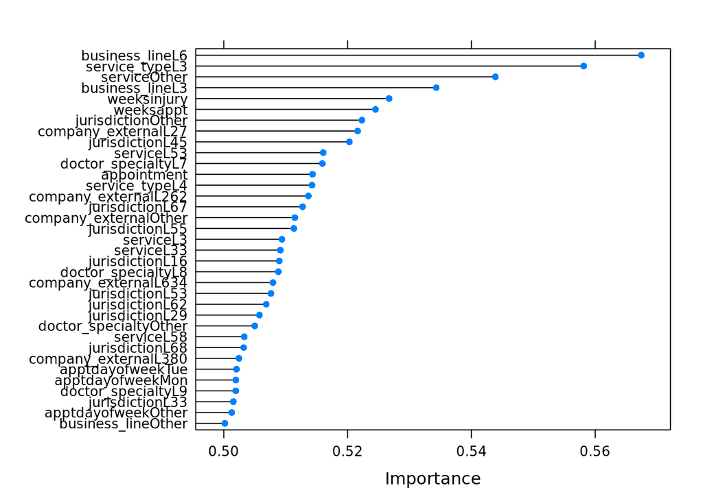

```r
importance <- varImp(SVM_Model, scale=FALSE)
plot(importance)
```

# Summary

Unfortunately, our classifers did not perform particularly well. We maxed out around 62.35% accuracy using a vanilla SVM model. Despite some basic attempts at feature engineering, cutting down on some of the variability of our observations, and simplifying our variable of interest to make a binary classifier, we didn’t improve initial performance by more than a few percentage points. Only moderately better than random guessing.

### Next Steps

Some proposed next steps we could take to improve our classifier performance:

- **Gather More Data**: Does the client have more data they can provide? Either more variables or (ideally) more records that could help us find additional signal? Alternatively, an active learning pilot where we could gather more real-time data to inform a model?
- **Combine with Secondary Datasets**: Are there other data resources we could combine with the existing data to provide additional signal?
- **SME**: Does the client have an SME that can help us see through the anonymized coding and extract new and useful features?
- **Model Tuning**: Take more care to find and tune the right model(s).
- **Ensembles**: Create an ensemble model derived from multiple weak ones. Perhaps > 70% is achievable.
- **Categorical Vars**: We could continue initial efforts to manage our anonymized categorical variables, attempting to derive continuous numeric products from them using methods like frequency calculations, row/column counts, etc.
- **Variable Treatment**: We could do an outlier review and see how those may be obscuring signal for prediction. We could also do more work to review correlation / variance to improve our feature selection. We could review alternative methods for centering and scaling our data.
- **Business Cost**: Better understand the business costs associated with predicting and improving patient scheduling. Understanding the costs would help us understand the threshold of accuracy a predictive model must acheive to be useful to the client.
- **Simulation**: For problems related to operations improvement, a common tool to aid in tasks like scheduling is simulation. Could we scope out a simulation project, generate random variables necessary for inputs, then run the simulations? The benefit here would be that in addition to better understanding the existing data, the client could compare and contrast simulations of potential scheduling solutions, ultimately aiding them in resource allocation.